# Анализ бизнес-показателей развлекательного приложения

## Маркетинг

- Посчитаем общую сумму расходов на маркетинг.
- Выясним, как траты распределены по рекламным источникам, то есть сколько денег потратили на каждый источник.
- Построим визуализацию динамики изменения расходов во времени (по неделям и месяцам) по каждому источнику.
- Узнаем, сколько в среднем стоило привлечение одного пользователя (CAC) из каждого источника.

```python
print('Общая сумма затрат на маркетинг:', costs['costs'].sum().round(0))
```

```
Общая сумма затрат на маркетинг: 105497.0
```

```python
cs = costs.groupby('channel').agg({'costs':'sum'}).sort_values(by='costs', ascending=False)
cs['cost_rate'] = (cs['costs']/(costs['costs'].sum())*100).round(1)
display(cs)
```

| channel | costs | cost_rate |
| --- | --- | --- |
| TipTop | 54751.30 | 51.9 |
| FaceBoom | 32445.60 | 30.8 |
| WahooNetBanner | 5151.00 | 4.9 |
| AdNonSense | 3911.25 | 3.7 |
| OppleCreativeMedia | 2151.25 | 2.0 |
| RocketSuperAds | 1833.00 | 1.7 |
| LeapBob | 1797.60 | 1.7 |
| lambdaMediaAds | 1557.60 | 1.5 |
| MediaTornado | 954.48 | 0.9 |
| YRabbit | 944.22 | 0.9 |

Из таблицы видно что больше половины общих затрат на маркетинг приходится на канал Tip Top, в то время как на канал YRabbit с минимальной суммой 944 приходится около 1%. Добавим столбцы с неделями и месяцами в таблицу расходов на маркетинг и построим графики динамик расходов.

```python
new_costs=costs
new_costs['dt']=pd.to_datetime(new_costs['dt'])
new_costs['week']=new_costs['dt'].dt.isocalendar().week
new_costs['month']=new_costs['dt'].dt.month
```

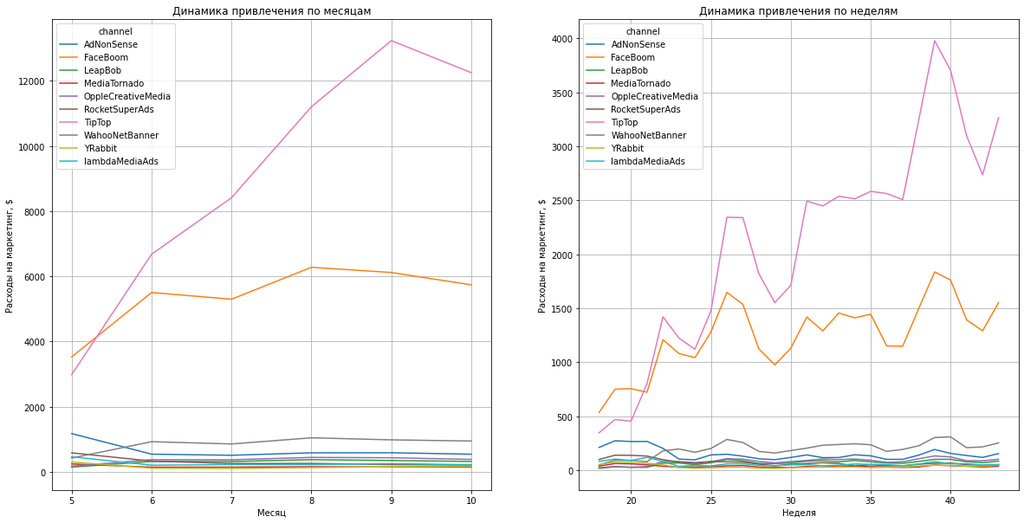

```python
plt.figure(figsize=(20,10))
ax1 = plt.subplot(1, 2, 1)
new_costs.pivot_table(
    index=['month'], columns=['channel'], values='costs', aggfunc='sum'
).plot(grid=True, ax=ax1)
plt.ylabel('Расходы на маркетинг, $')
plt.xlabel('Месяц')
plt.title('Динамика привлечения по месяцам')
ax2 = plt.subplot(1, 2, 2)
new_costs.pivot_table(
    index=['week'], columns=['channel'], values='costs', aggfunc='sum'
).plot(grid=True, ax=ax2)
plt.ylabel('Расходы на маркетинг, $')
plt.xlabel('Неделя')
plt.title('Динамика привлечения по неделям')
plt.show()
```

Итак, по графикам динамики расходов большую часть рассматриваемого периода по расходам тот же лидер канал Tip Top. Лишь в начале мая на FaceBoom выделено больше средств. Затраты на Tip Top с мая по сентябрь платежи заметно растут, а с сентября по октабрь падают.

Рассчитаем среднюю стоимость привлечения одного пользователя (CAC) из каждого источника.

```python
display(profiles.query('channel!="organic"').groupby('channel').agg({'acquisition_cost':'mean'}).sort_values(by='acquisition_cost', ascending=False))
```

| channel | acquisition_cost |
| --- | --- |
| TipTop | 2.799003 |
| FaceBoom | 1.113286 |
| AdNonSense | 1.008054 |
| lambdaMediaAds | 0.724802 |
| WahooNetBanner | 0.602245 |
| RocketSuperAds | 0.412095 |
| OppleCreativeMedia | 0.250000 |
| YRabbit | 0.218975 |
| MediaTornado | 0.218717 |
| LeapBob | 0.210172 |

```python
print('Средний показатель привлечения пользователей (САС):', profiles.query('channel!="organic"')['acquisition_cost'].mean().round(1))
```

```
Средний показатель привлечения пользователей (САС): 1.1
```

#### **Выводы:**

- Общие затраты на маркетинг - 105497.0.
- По затратам на маркетинг лидирует канал TipTop - 51,9%, далее идет Faceboom - 30,8%. Затраты по остальным каналам не превышают 5%.
- По стоимости привлечения одного пользователя (САС) также впереди TipTop - 2,8, что > чем в 2 раза выше среднего, далее FaceBoom - 1,1, а следом остальные по убыванию до 21 цента.

к содержанию

## Оценка окупаемости рекламы

Для корректной оценки окупаемости прежде всего исключим пользователей с органическим трафиком.

```python
profiles = profiles.query('channel!="organic"')
```

```python
ltv_raw, ltv, ltv_in_time, roi, roi_in_time = get_ltv(profiles, orders, observation_date, horizon)
```

**Анализ окупаемости рекламы c помощью графиков LTV и ROI, а также графиков динамики LTV, CAC и ROI**

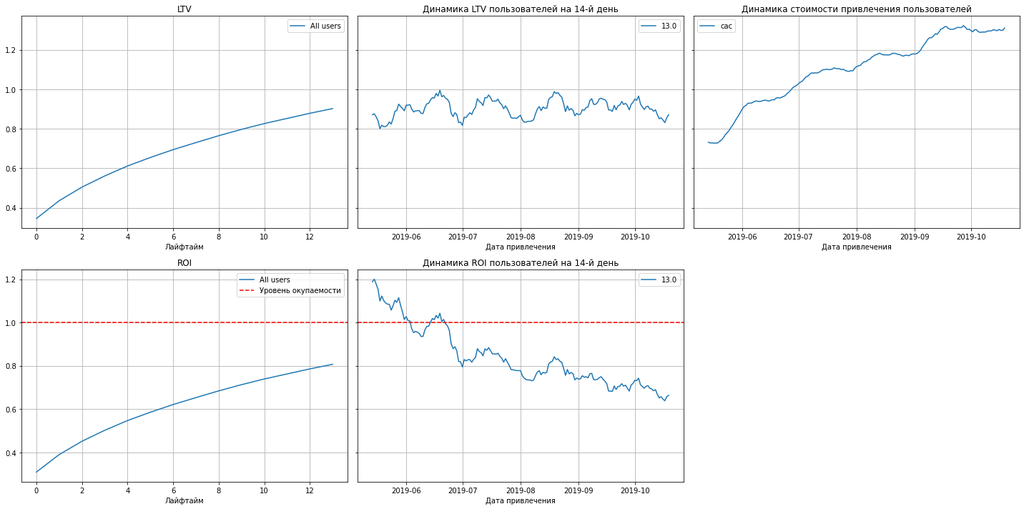

```python
plot_ltv_roi(ltv, ltv_in_time, roi, roi_in_time, horizon, window=14)
```

**Анализ конверсии и удержания пользователей и динамика их изменений.**

```python
conversion_raw, conversion, conversion_history = get_conversion(profiles, orders, observation_date, horizon, dimensions=[])
```

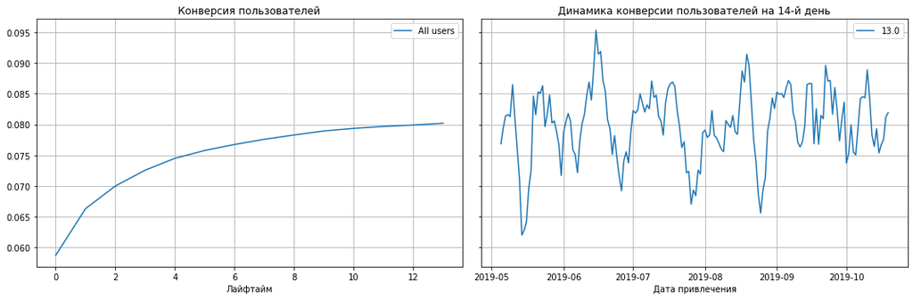

```python
plot_conversion(conversion, conversion_history, horizon, window=5)
```

Общая конверсия пользователей изменяется в горизонте 14 дней с 5,9 до 8%. Динамика конверсии на 14 день лайфтайма нестабильна, с колебаниями относительно 8% с минимумом 6,2% и максимумом 9,5%.

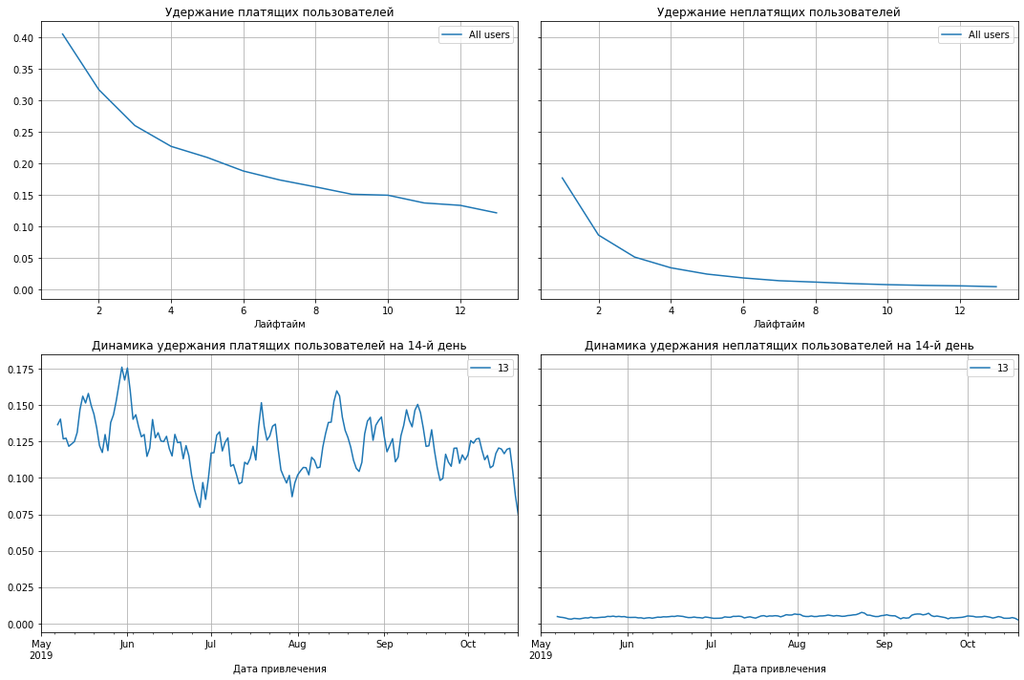

```python
plot_retention(retention, retention_history, horizon, window=7)
```

Удержание платящих пользователей от 41 до 12% в горизонте 14 дней, а неплатящих от 18 до 1%. Динамика удержания платящих пользователей на 14 день колеблется в районе 12,5 %, причем амплитуда колебаний с июня по июль максимальная, а с сентября до конца октября минимальная. Динамика изменения неплатящих пользователей приближается к константе около 1%.